#### Network plot - Contemporaneous connectedness

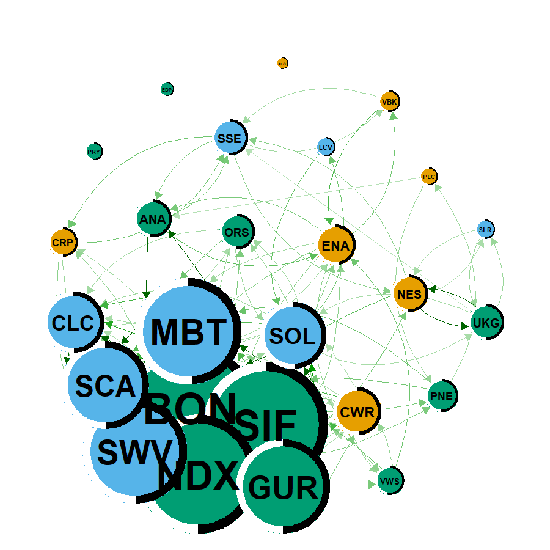

```r
gc <- net_plot(
  R2conL$TABLE$Contemporaneous, Cnames,
  layout = "spring",
  groups = groups, div = 5,
  node.size = 35, edge = 3,
  pie.colour = c("black","white")
)
```

#### Network plot - Lag connectedness

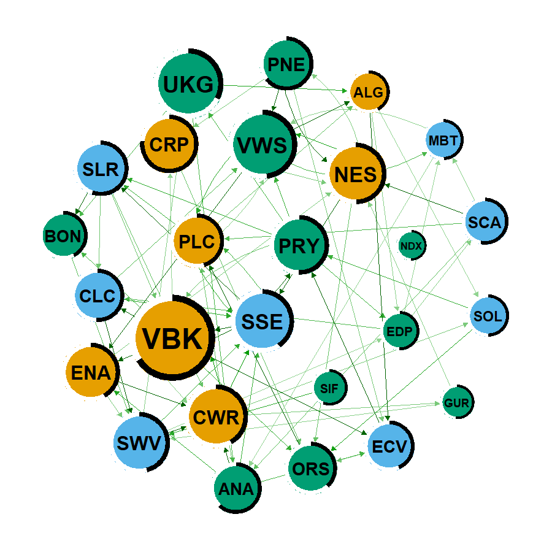

```r
gl <- net_plot(
  R2conL$TABLE$Lagged, Cnames,
  layout = "spring",
  groups = groups, div = 8,
  node.size = 35, edge = 2,
  pie.colour = c("black","white")
)
```

## Figure 2. Time-varying lower tail total connectedness index among European renewable energy companies

For dynamics we use a 200-day window on the 5-firm subset (fast enough to render).

```r
dca <- R2ConnectednessQ(
  renewable_residuals[,1:5],
  window.size = 200,
  nlag = 1,
  quantile = TRUE,
  q = 0.05,
  method = "pearson",
  shrink = TRUE,
  progbar = FALSE
)
TCI <- dca$TCI
head(TCI)
```

```
#>             Overall Contemporaneous   Lagged
#> 2017-10-13 15.94088        11.87311 4.067770
#> 2017-10-16 15.65963        11.69132 3.968305
#> 2017-10-17 15.65698        11.68220 3.974778
#> 2017-10-18 15.96980        11.68576 4.284041
#> 2017-10-19 14.53213        11.14634 3.385783
#> 2017-10-20 16.28941        11.64794 4.641471
```

```r
df <- cbind.data.frame(as.Date(rownames(TCI)), TCI[, 1:3, drop = FALSE])
colnames(df) <- c("date", "SOI", "SOIC", "SOIL")
```

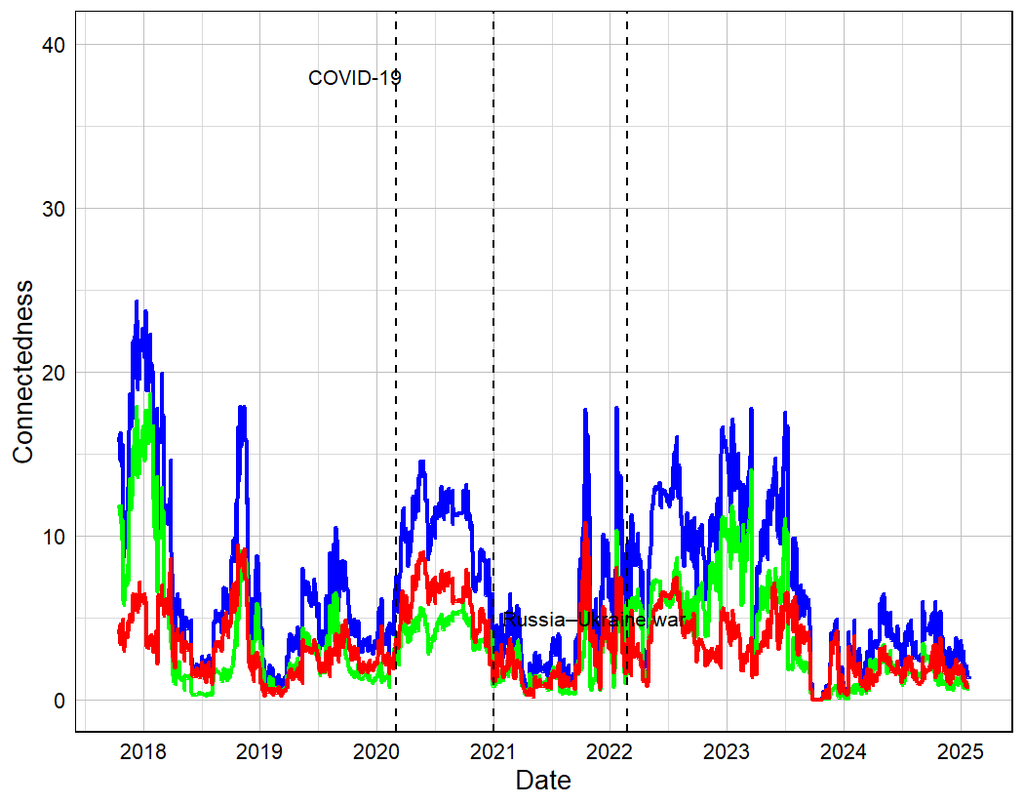

```r
library(ggplot2)

ymin <- 0; ymax <- 40

mytheme <- theme(
  panel.background = element_rect(fill = "transparent"),
  panel.border     = element_rect(fill = "transparent", color = "black", linewidth = 0.6),
  text             = element_text(size = 13, color = "black"),
  axis.text.x      = element_text(color = "black"),
  axis.text.y      = element_text(color = "black"),
  panel.grid.major = element_line(size = 0.1, colour = "grey75"),
  panel.grid.minor = element_line(size = 0.05, colour = "grey85"),
  legend.position  = "bottom",
  legend.title     = element_blank()
)

g_tci <- ggplot(df, aes(x = date)) +
  geom_line(aes(y = SOI),  color = "blue",  linewidth = 0.9) +
  geom_line(aes(y = SOIC), color = "green", linewidth = 0.9) +
  geom_line(aes(y = SOIL), color = "red",   linewidth = 0.9) +
  theme_minimal() +
  coord_cartesian(ylim = c(ymin, ymax)) +
  labs(y = "Connectedness", x = "Date") +
  scale_x_date(date_breaks = "1 year", date_labels = "%Y") +
  geom_vline(xintercept = as.Date("2020-03-01"), linetype = "dashed") +
  geom_vline(xintercept = as.Date("2021-01-01"), linetype = "dashed") +
  geom_vline(xintercept = as.Date("2022-02-24"), linetype = "dashed") +
  annotate("text", x = as.Date("2019-06-01"), y = ymax - 2,
           label = "COVID-19", size = 3.6, hjust = 0) +
  annotate("text", x = as.Date("2021-01-30"), y = ymin + 5,
           label = "Russia–Ukraine war", size = 3.6, hjust = 0) +
  mytheme

g_tci
```

## References

- Balli, F., Balli, H. O., Louis, R. J., & Pappas, V. (2023). *Dynamic Connectedness Across Markets: Revisiting the R² Approach.* Finance Research Letters, 56, 104263.
- Choi, S., & Shin, S. (2022). *Quantile Correlation: Measuring Dependence at Different Quantiles.* Journal of Econometrics, 226(1), 1–24.
- Ferrer, R., Shahzad, S. J. H., Furió, D., & Benammar, R. (2025). *Systemic Risk in the Tails: Contemporaneous Transmission and Spillover Dynamics in European Renewable Energy Equities.* Submitted for publication.
- Hoang, T. H. V., & Baur, D. G. (2022). *R² Connectedness: Measuring Integration and Contagion in Financial Markets.* Journal of Financial Econometrics, 20(3), 520–544.